# Нейронные сети и прогнозирование временного ряда.

©Alexander Doynikov,dep. CS, MSU

March 18, 2021

# Краткое введение в нейронные сети

Нейронная сеть это математическая модель построенная исходя из принципов функционирования головного мозга и представляет собой систему взаимодействующих между собой искусственных нейронов.Каждый нейрон имеет дело только с сигналами, которые он периодически получает, и сигналами, которые он периодически посылает другим нейронам. Нейронные сети позволяют решать статистические задачи классификации, кластеризации, прогнозирования временных рядов, задачи распознавания образов, моделирования естественного интеллекта.

Главное приемущество нейронных систем это возможность обучения, которое заключается в постепенном (в процессе обучения) оценке коэффициента связи с другими нейронами сети.

По построению нейронные сети можно поделить на однонаправленные, когда сигнал передается со слоя на слой последовательно, и на сети, где есть петли обратной связи. Однонаправленные сети гарантированно закончат свою работу. Поведение сетей с обратной связью, вообоще говоря, непредсказуемо. В этом случае следует принимать специальные меры к тому, чтобы сеть не зацикливалась.

Исторически первые появились сети на основе перцептрона - кибернетическая модель мозга, предложенной Фрэнком Розенблаттом в 1957 году.Перцептрон состоит из трёх типов элементов, а именно: поступающие от сенсоров сигналы передаются ассоциативным элементам, а затем реагирующим элементам.Чтобы «научить» перцептрон классифицировать образы, был разработан специальный итерационный метод обучения проб и ошибок, напоминающий процесс обучения человека — метод коррекции ошибки.

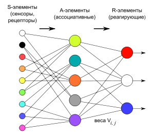

Логическая схема перцептрона представлена на рисунке.

Поступающая через вход информация обрабатывается в нейроне в 2 этапа: На первом этапе вычисляется взвешенная сумма:
$$S = \sum_{i=1}^n\omega_i X_i + O$$
Число О — порог.

Обычно, для унификации записи порог рассматривается как вес тупой связи, то есть связи которая все время генерирует 1. И тогда можно записать как:
$$S = \sum_{i=0}^n\omega_i X_i$$

где
$$X_0 = 1, \omega_0 = O$$
Это так называемый классический нейрон сокращенно КН.

В обобщённом КН выступают вероятностные меры, где число О — случ. величина чаше всего с нормальным распределением $N(0, G)$

Алгебраический нейрон это нейрон, где сумма S нелинейна.

Выход нейрона — $Y$. определяется как некоторая функция от взвешенной суммы.
$$y = f(s)$$
Функция $f$ — функция активации.

## Примеры функций активации

1.Простая кусочно-линейная функция. Если входное значение меньше порогового, то значение функции активации равно минимальному допустимому, иначе – максимально допустимому.

2.Несложная кусочно-линейная функция. Имеет два линейных участка, где функция активации тождественно равна минимально допустимому и максимально допустимому значению и есть участок, на котором функция строго монотонно возрастает.

3.Сигмоидальная функция или сигмоид.

Монотонно возрастающая всюду дифференцируемая S-образная нелинейная функция с насыщением. Сигмоид позволяет усиливать слабые сигналы и не насыщаться от сильных сигналов. Примером сигмоидальной функции активации может служить логистическая функция, задаваемая следующим выражением:
$$f(s)=\frac{1}{1+e^{-\alpha s}}$$

Еще одним примером сигмоидальной функции активации является гиперболический тангенс, задаваемый следующим выражением:
$$f(s)=tanh(s)=\frac{e^s-e^{-s}}{e^s+e^{-s}}$$

# Построение оптимальной архитектуры нейронной сети для проноза временного ряда

Сначала определимся с функцией активации Задача прогнозирования временного ряда сродни задачи регрессии, в которых чаще всего используется тождественная функция
$$y = f(x) = x$$
Здесь мы рассмотрим основную идею задания оптимальной архитектуры нейронной сети для прогнозирования временного ряда, модель которого известна. Предположим, что строится прогноз временного ряда $y_t$, заданного моделью авторегрегресии порядка 3 (AR(3)-модель).
$$y_t = \nu+\phi_1y_{t-1}+\phi_2y_{t-2}+\phi_3y_{t-3}+\epsilon_t$$
Исходя из вида модели AR(3) наиболее оптимальной архитектурой нейронной сети напрашивается сеть с 3 входами и одним выходом (относительно скрытого уровня нейронов поговорим позднее). Пусть временной ряд $y_t$ состоит из 24 наблюдений, $y_1,y_2,...,y_{23},y_{24}$ тогда расположим наблюдения $y_t$ в виде матрицы
$$\begin{equation*}\left[ \begin{matrix}\
y_1&y_2&y_3&y_4\\
y_2&y_3&y_4&y_5\\
y_3&y_4&y_5&y_6\\
...\\
y_{21}&y_{22}&y_{23}&y_{24}\\
\end{matrix}\right] \end{equation*}$$
Первые 3 столбца будем считать входом нейронной сети, а четвертый столбец выходом нейронной сети.

В сезонной моделе все гороаздо сложнее Для сезонного ряда авторегрессии с периодом сезоннсти $S=8$, и моделью
$$\Phi_2(B^S)\phi_2(B)y_t=\epsilon_t$$
где
$$\Phi_2(B^S)=1-\Phi_1B^S-\Phi_2B^{2S}$$
$$\phi_2(B)=1-\phi_1B-\phi_2B^2$$
Перемножая полинономы $\Phi_2(B^S)$ и $\phi_2(B)$, получим
$$\Phi_2(B^S)\phi_2(B)y_t=$$
$$(1-\Phi_1B^S-\Phi_2B^{2S}-\phi_1B-\phi_2B^{2}+\Phi_1\phi_1B^{S+1}+\Phi_1\phi_2B^{S+2}+\Phi_2\phi_1B^{2S+1}+\Phi_2\phi_2B^{2S+2})y_t$$
отсюда
$$y_t=\phi_1y_{t-1}+\phi_2y_{t-2}+\Phi_1y_{t-S}+\Phi_2y_{t-2S}-\Phi_1\phi_1y_{t-S-1}-\Phi_1\phi_2y_{t-S-2}-\Phi_2\phi_1y_{t-2S-1}-\Phi_2\phi_2y_{t-2S-2}$$
при периоде сезонности $S=8$
$$y_t=\phi_1y_{t-1}+\phi_2y_{t-2}+\Phi_1y_{t-8}-\Phi_1\phi_1y_{t-9}-\Phi_1\phi_2y_{t-10}+\Phi_2y_{t-16}-\Phi_2\phi_1y_{t-17}-\Phi_2\phi_2y_{t-18}$$
Таким образом вход и выход нейронной сети для ряда $y_1,y_2,...,y_{23},y_{24}$ в виде матрицы следует задать так
$$\begin{equation*}\left[ \begin{matrix}\
y_1&y_2&y_3&y_9&y_{10}&y_{11}&y_{17}&y_{18}&y_{19}\\
y_2&y_3&y_4&y_{10}&y_{11}&y_{12}&y_{18}&y_{19}&y_{20}\\
...\\
y_8&y_7&y_8&y_{14}&y_{15}&y_{16}&y_{22}&y_{23}&y_{24}\\
\end{matrix}\right] \end{equation*}$$
Крайний правый столбец это выход нейронной сети, а первые 8 столбцов это вход сети. Для работы с нейронными сетями в R обычно используется пакет `neuralnet`. Но подготовка архитектуры сети для учета автокорреляционных связей во временном ряде весьма трудоемкая в программном смысле задача.

# Пакет forecast

`forecast` — это пакет, написанный Робом Хайндманом (Rob J. Hyndman), содержит различные методы прогнозирования временных рядов, включая и знакомые нам уже ARMA и SARMA прогнозирование. Но мы из этого пакета коснемся только одного метода прогнозирования временного ряда посредством нейронных сетей `nnetar()`. В нем эта неприятная процедура построения входа и выхода для сезонных временных рядов реализована, что значительно облегчает труд программиста.

```r
library(forecast)
```

Умение грамотно идентифицировать порядки сезонной модели авторегрессии здесь имеет очень важное значение. Про модели скользящего среднего скажем позднее. В прошлой лекции мы идентифицировали временной ряд импорта России как сезонную модель $SARMA(0,1,3)(0,1,1)$ с периодом сезонности $S=12$. Но это модель скользящего среднего, а нам нужна авторегрессия. Возращаясь к виду ACF и PACF для ряда разностей можно модель также идентифицировать как $SARMA(4,1,0)(2,1,0)$. Мы ее там пробовали, но она оказалась чуть хуже, чем $SARMA(0,1,3)(0,1,1)$ В итоге мы получили, что несезонный порядок авторегресии $p=5$, а сезонный порядок $P = 3$. Почему?

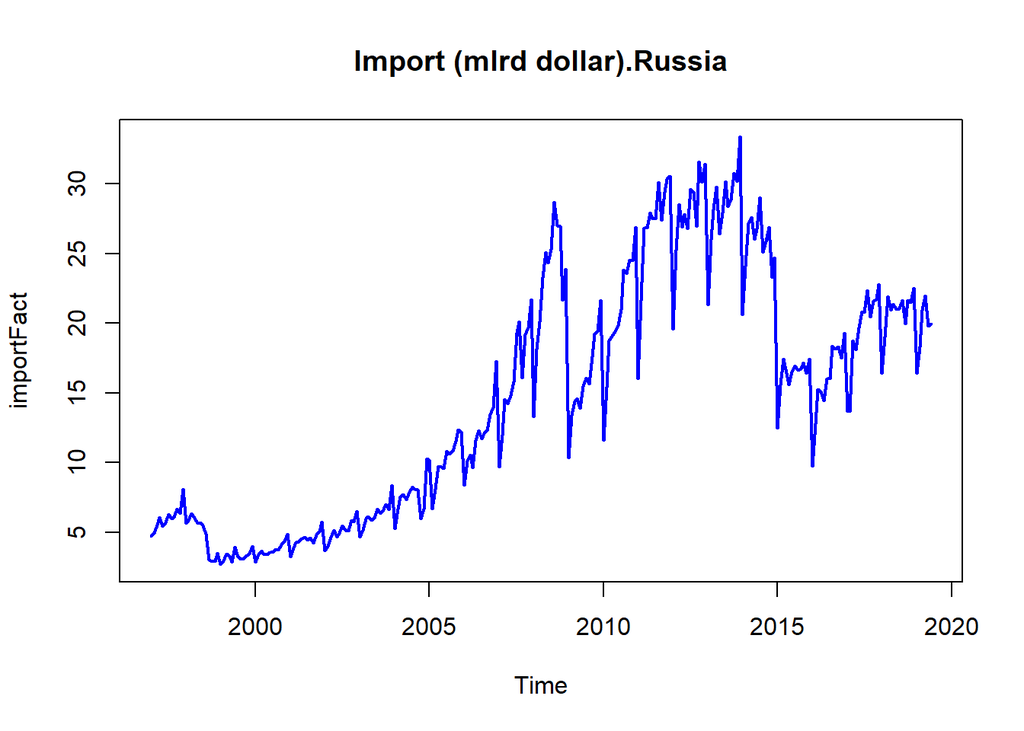

```r
 import <- read.csv("./import.csv", header = TRUE)
 importFact <- ts(import$Fact ,start= c(1997,1),frequency =12)
 plot(importFact ,type = "l", col = "blue",lwd = 2,main = "Import (mlrd dollar).Russia")
```

Обучим нейронную сеть

```r
  p <- 5
  P <- 3
  library(forecast)
  nnet<- nnetar(importFact,p=p,P = P,size = 10 )
```

Количество нейронов в скрытом уровне мы взяли равным 10. Построим прогноз на год вперед

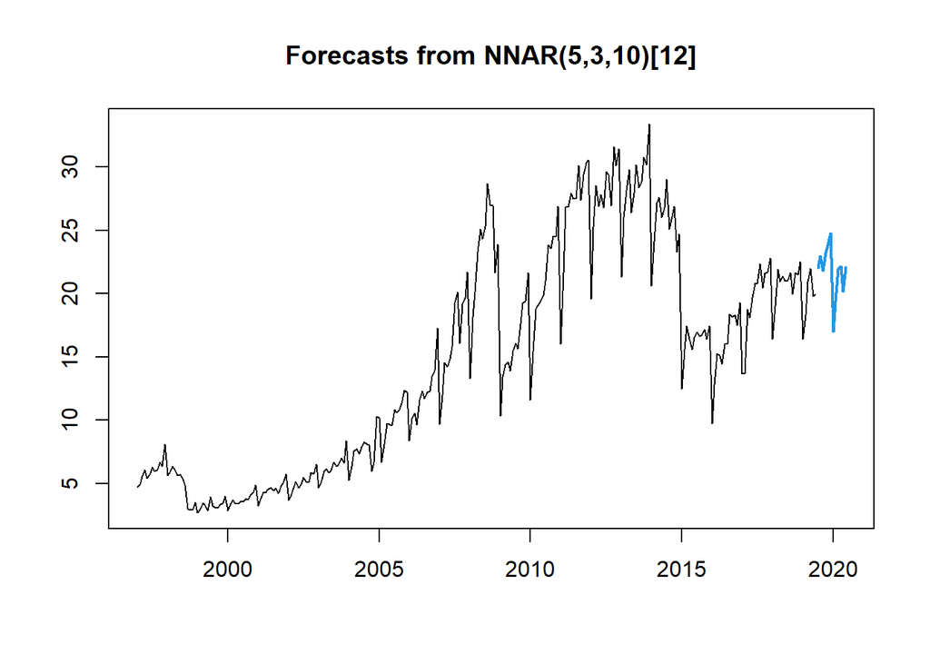

```r
fcast <- forecast(nnet,h = 12)
plot(fcast)
```

```r
summary(nnet)
```

```
##           Length Class        Mode
## x         270    ts           numeric
## m           1    -none-       numeric
## p           1    -none-       numeric
## P           1    -none-       numeric
## scalex      2    -none-       list
## size        1    -none-       numeric
## subset    270    -none-       numeric
## model      20    nnetarmodels list
## nnetargs    0    -none-       list
## fitted    270    ts           numeric
## residuals 270    ts           numeric
## lags        8    -none-       numeric
## series      1    -none-       character
## method      1    -none-       character
## call        5    -none-       call
```

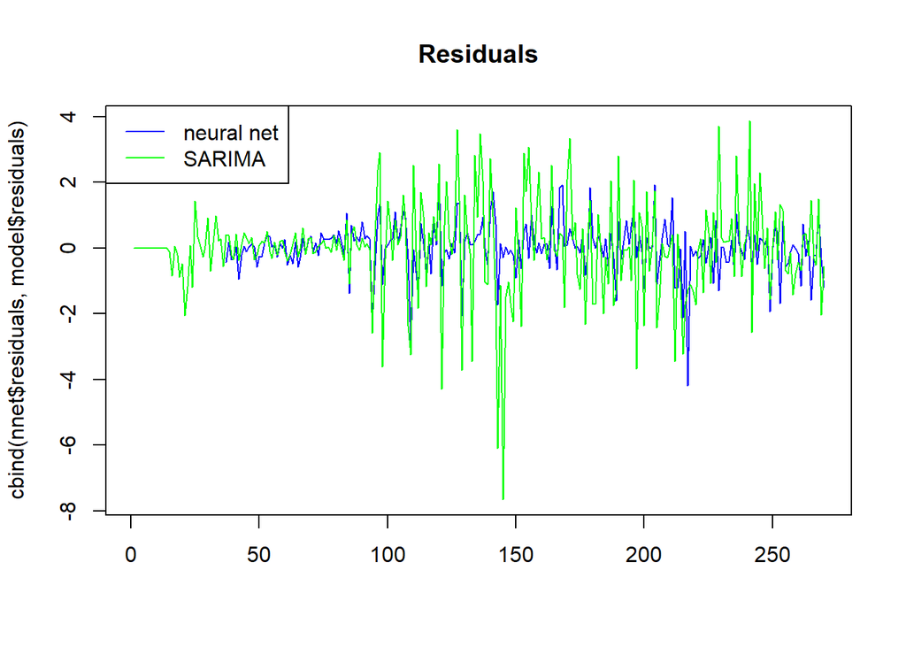

```r
model <-arima(importFact,order = c(0,1,1),seasonal = list(order = c(0,1,3),period=12), method="CSS")

matplot(cbind(nnet$residuals,model$residuals),type = 'l',main = 'Residuals', lty= 1,col = c("blue",'green'))
legend('topleft',c('neural net','SARIMA'),lty = 1,col = c("blue",'green'))
```

```r
mean(nnet$residuals[100:241]^2)
```

```
## [1] 0.7625757
```

```r
mean(model$residuals[100:241]^2)
```

```
## [1] 3.395155
```

```r
nnet$model
```

```
##
## Average of 20 networks, each of which is
## a 8-10-1 network with 101 weights
## options were - linear output units
```

# Пакет Prophet

Прогнозирование временных рядов — это весьма популярная аналитическая задача. Мы уже попробовали решать эту задачу с использованием моделей ARIMA и SARIMA, позднее попробуем использовать подход ARCH,GARCH. Здесь мы попробуем использовать библиотеку *Prophet* от компании Facebook. 23 февраля 2017 года команда Core Data Science из Facebook выпустила новую библиотеку для автоматического прогнозирования временных рядов — *Prophet*. Попробуем применить новую библиотеку и посмотрим на удобство в использовании и качество предсказания.Библиотека была выпущена для Python и R одновременно.

Подробно ознакомиться с алгоритмом установки библиотеки *prophet* для работы в R и в Python можно здесь https://facebook.github.io/prophet/

Итак, будем считать, что установка прошла успешно рассмотрим первый пример прогнозирования курса доллара.

## Пример 1. Прогнозирование обменного курса RUB/USD

Загрузим требуемые библиотеки

```r
suppressWarnings(library(prophet))
suppressWarnings(library(dplyr))
```

Считываем данные

```r
mydata <- read.csv('./RubleBrent.csv')
colnames(mydata)<- c('ds','y','brent')
data <- as.data.frame(mydata)

data[,1] <- as.Date(data[,1],"%m/%d/%y")
head(data)
```

```
##           ds       y brent
## 1 2010-01-04 29.9710 80.24
## 2 2010-01-05 29.9250 80.71
## 3 2010-01-06 29.8630 81.82
## 4 2010-01-07 29.8650 81.47
## 5 2010-01-08 29.8650 81.46
## 6 2010-01-11 29.3055 81.29
```

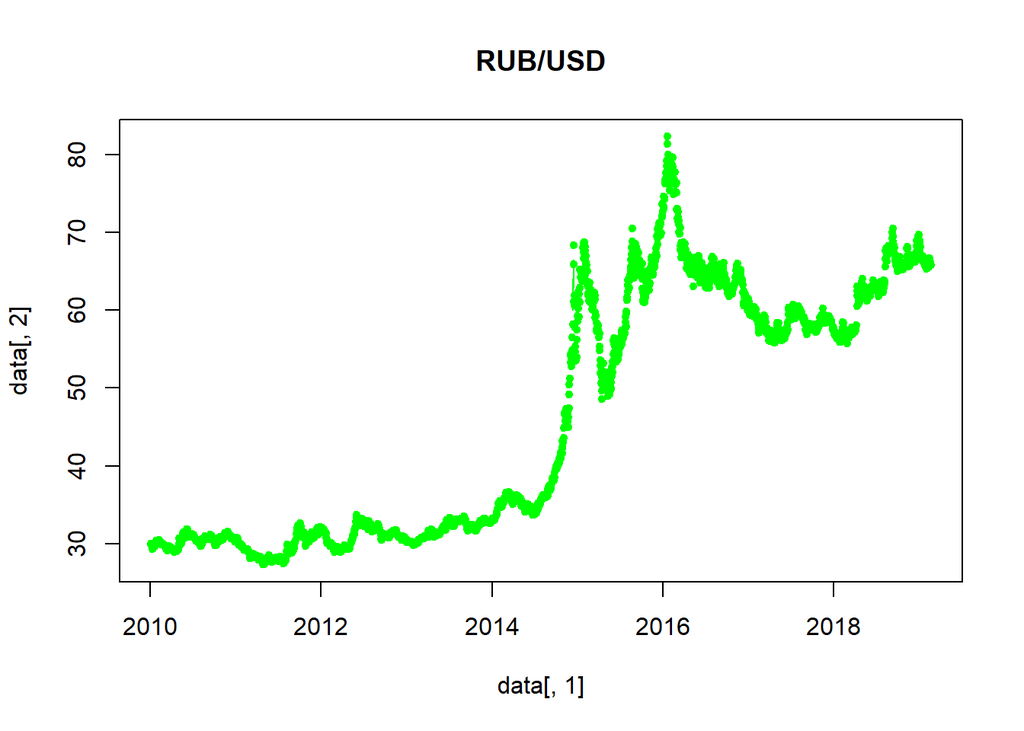

```r
plot(data[,1],data[,2],type = 'b',pch = 20,main = 'RUB/USD',col = 'green')
```

Кроме курса доллара данные содержат соответствующие этим календарным датам цены на нефть марки Brent. Здесь мы уже замечаем первые “неудобства” - библиотека *prophet* требует, чтобы колонка с датами называлась `ds`, а колонка с прогнозируемым рядом - `y`. Переменная с данными должна быть определена как `data.frame` Цена нефти марки Brent будет позднее добавлена как дополнительный предиктор (регрессор). Но сначала начнем прогнозирование без нефти.

```r
head(ruble <- data[,1:2])
```

```
##           ds       y
## 1 2010-01-04 29.9710
## 2 2010-01-05 29.9250
## 3 2010-01-06 29.8630
## 4 2010-01-07 29.8650
## 5 2010-01-08 29.8650
## 6 2010-01-11 29.3055
```

```r
r_ruble <- prophet(ruble)
```

```
## Disabling daily seasonality. Run prophet with daily.seasonality=TRUE to override this.
```

```r
head(r_ruble)
```

```
## $growth
## [1] "linear"
##
## $changepoints
##  [1] "2010-04-17 GMT" "2010-07-29 GMT" "2010-11-14 GMT" "2011-03-03 GMT"
##  [5] "2011-06-23 GMT" "2011-10-12 GMT" "2012-02-01 GMT" "2012-05-24 GMT"
##  [9] "2012-09-07 GMT" "2012-12-23 GMT" "2013-04-08 GMT" "2013-07-24 GMT"
## [13] "2013-11-18 GMT" "2014-03-11 GMT" "2014-06-27 GMT" "2014-10-12 GMT"
## [17] "2015-02-03 GMT" "2015-05-18 GMT" "2015-08-27 GMT" "2015-12-08 GMT"
## [21] "2016-03-22 GMT" "2016-07-05 GMT" "2016-10-14 GMT" "2017-01-31 GMT"
## [25] "2017-05-14 GMT"
##
## $n.changepoints
## [1] 25
##
## $changepoint.range
## [1] 0.8
##
## $yearly.seasonality
## [1] "auto"
##
## $weekly.seasonality
## [1] "auto"
```

Метод `prophet()` осуществляет оценку модели вида
$$y_t = m_t+s_t+u_t+\epsilon_t$$
здесь

$m_t$ - кусочно-линейная модель тренда с моментами изменения параметров линейной модели (`change points`) $t_1,...,t_k$, которые определяются автоматически, хотя можно их и предварительно задать;

$s_t$ - одна или композиция нескольких сезонных компонент;

$u_t+\epsilon_t$ - модель стационарной составляющей временного ряда.

Метод `summary(r_ruble)` для оцененной модели не содержит особой информации об оцененной модели

```r
summary(r_ruble)
```

```
##                         Length Class      Mode
## growth                     1   -none-     character
## changepoints              25   POSIXct    numeric
## n.changepoints             1   -none-     numeric
## changepoint.range          1   -none-     numeric
## yearly.seasonality         1   -none-     character
## weekly.seasonality         1   -none-     character
## daily.seasonality          1   -none-     character
## holidays                   0   -none-     NULL
## seasonality.mode           1   -none-     character
## seasonality.prior.scale    1   -none-     numeric
## changepoint.prior.scale    1   -none-     numeric
## holidays.prior.scale       1   -none-     numeric
## mcmc.samples               1   -none-     numeric
## interval.width             1   -none-     numeric
## uncertainty.samples        1   -none-     numeric
## specified.changepoints     1   -none-     logical
## start                      1   POSIXct    numeric
## y.scale                    1   -none-     numeric
## logistic.floor             1   -none-     logical
## t.scale                    1   -none-     numeric
## changepoints.t            25   -none-     numeric
## seasonalities              2   -none-     list
## extra_regressors           0   -none-     list
## country_holidays           0   -none-     NULL
## stan.fit                   4   -none-     list
## params                     5   -none-     list
## history                    5   data.frame list
## history.dates           2736   POSIXct    numeric
## train.holiday.names        0   -none-     NULL
## train.component.cols       4   data.frame list
## component.modes            2   -none-     list
## fit.kwargs                 0   -none-     list
```

Метод `make_future_dataframe()` подготовит ряд будущих дат прогнозов аж на целый год вперед (удивлять так удивлять).

```r
future_ruble <- make_future_dataframe(r_ruble, periods = 365)
tail(future_ruble)
```

```
##              ds
## 3096 2020-02-15
## 3097 2020-02-16
## 3098 2020-02-17
## 3099 2020-02-18
## 3100 2020-02-19
## 3101 2020-02-20
```

Метод `predict()` построим прогноз, метод `plot` покажет результат прогнозирования c доверительным интервалом, а метод `prophet_plot_components()` покажет оценки тренда и оценки, автоматически определенных сезонных компонент. В нашем случае это окажется недельная и годовая сезоннная компонента. Обратим внимание, что это все сделано на полном автомате.

```r
forecast_ruble <- predict(r_ruble, future_ruble)
tail(forecast_ruble[c('ds', 'yhat', 'yhat_lower', 'yhat_upper')])
```

```
##              ds     yhat yhat_lower yhat_upper
## 3096 2020-02-15 72.81612   53.77332   94.25912
## 3097 2020-02-16 72.76037   52.72621   93.70903
## 3098 2020-02-17 72.72818   53.57219   94.61027
## 3099 2020-02-18 72.71208   51.75156   94.51401
## 3100 2020-02-19 72.67102   51.38147   94.58270
## 3101 2020-02-20 72.63848   52.42976   94.65015
```

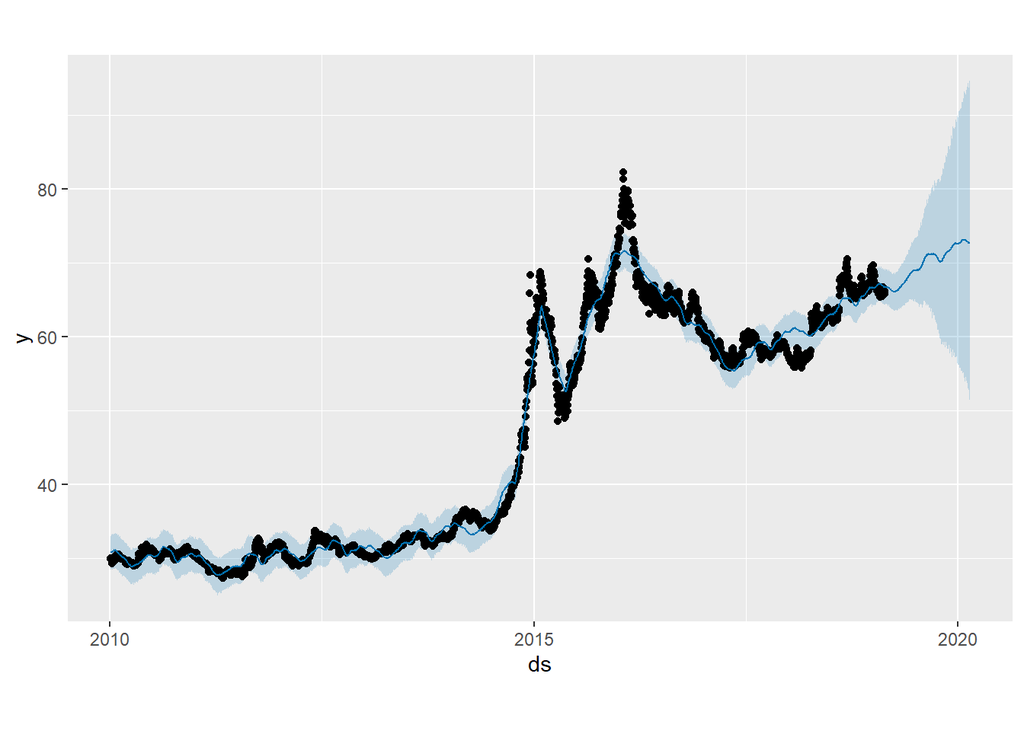

```r
plot(r_ruble, forecast_ruble)
```

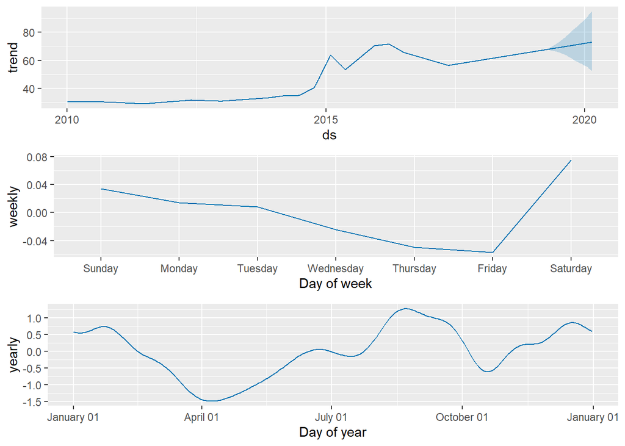

```r
prophet_plot_components(r_ruble, forecast_ruble)
```

## Дополнительный предиктор

Создадим объект типа `prophet`, но пока без оценки (переменная fit = FALSE).

```r
r_withregressor <- prophet(brent,fit = FALSE)
```

Добавим предиктор `brent` в модель и произведем оценку модели с добавленным предиктором

```r
r_withregressor<- add_regressor(r_withregressor, 'brent')
r_withregressor <- fit.prophet(r_withregressor,data)
```

```
## Disabling daily seasonality. Run prophet with daily.seasonality=TRUE to override this.
```

Построим исторический прогноз курса рубля (без прогноза курса в будущем, так как для построения прогноза в будущем потребуется прогноз будущих цен на нефть).

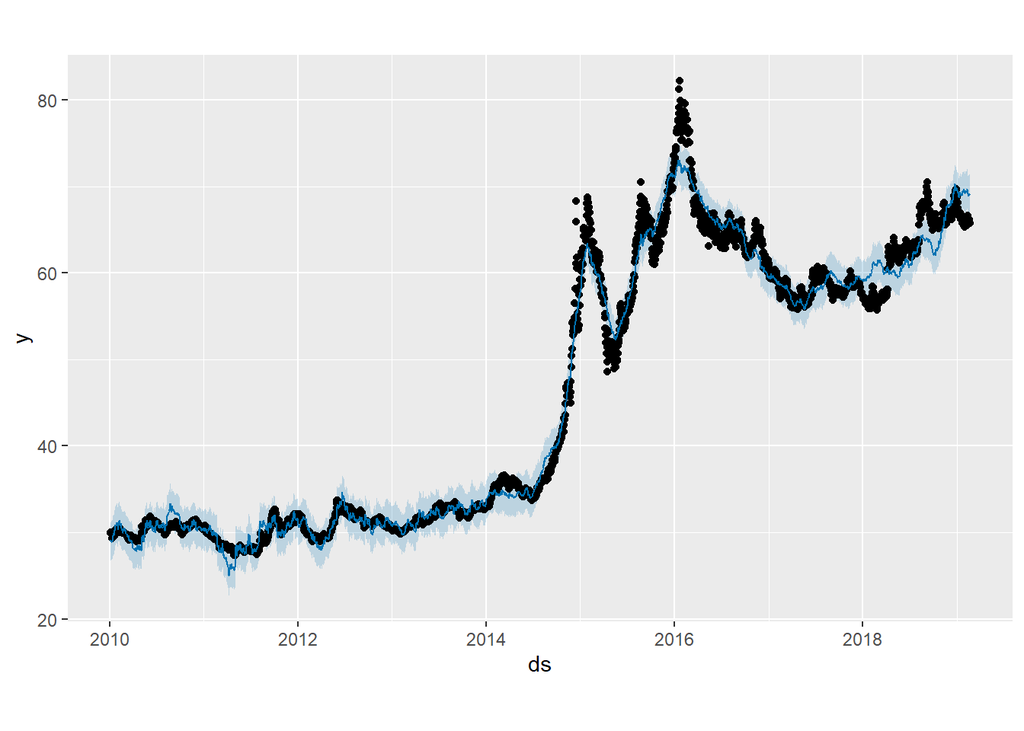

```r
forecast_withregressor <- predict(r_withregressor)
plot(r_withregressor, forecast_withregressor)
```

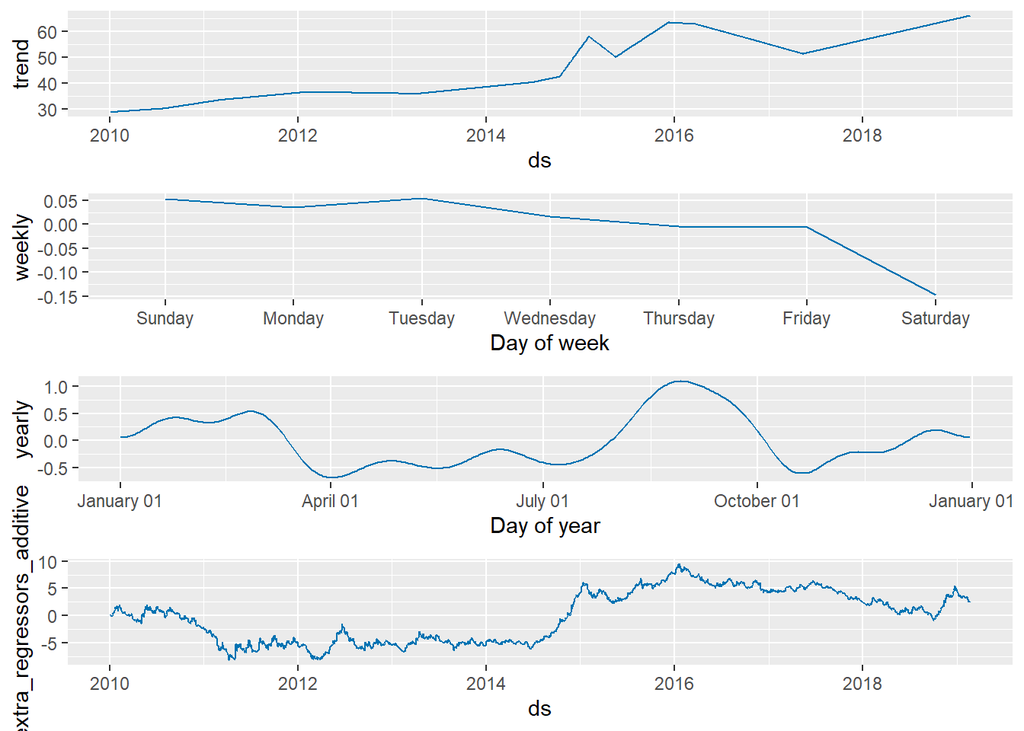

```r
prophet_plot_components(r_withregressor,  forecast_withregressor)
```

Сравним среднюю сумму квадратов ошибки прогнозов по модели без добавленного предиктора и для модели с предиктором.

```r
forecast_ruble_without <- predict(r_ruble)
mean_without_regressor<- mean((forecast_ruble_without$yhat-data$y)^2)
mean_with_regressor<- mean((forecast_withregressor$yhat-data$y)^2)
list(mean_error_without_regressor= mean_without_regressor,mean_error_with_regressor=mean_with_regressor)
```

```
## $mean_error_without_regressor
## [1] 3.430723
##
## $mean_error_with_regressor
## [1] 3.110483
```

```r
ind8march <- which(substr(mydata[,1], 1, 5)=="03/08")
futhol <- as.Date("03/08/18","%m/%d/%y")
(ds <-c(data[ind8march,1],futhol))
```

```
## [1] "2010-03-08" "2011-03-08" "2012-03-08" "2013-03-08" "2015-03-08"
## [6] "2016-03-08" "2017-03-08" "2018-03-08" "2018-03-08"
```

Создадим переменную hols типа `data.frame` и куда занесем подготовленный ранее вектор дат и сообщим, что время подготовки к празднику 5 дней,а последствия сказываются 2 дня.

```r
hols <- data.frame(
      holiday = 'march_8',
      ds = ds,
      lower_window = -5,
      upper_window = 2
    )
hols
```

```
##   holiday         ds lower_window upper_window
## 1 march_8 2010-03-08           -5            2
## 2 march_8 2011-03-08           -5            2
## 3 march_8 2012-03-08           -5            2
## 4 march_8 2013-03-08           -5            2
## 5 march_8 2015-03-08           -5            2
## 6 march_8 2016-03-08           -5            2
## 7 march_8 2017-03-08           -5            2
## 8 march_8 2018-03-08           -5            2
## 9 march_8 2018-03-08           -5            2
```

Оценим модель с заданным набором праздников и посмотрим результаты

```r
r_ruble1 <- prophet(ruble,holidays = hols)
```

```
## Disabling daily seasonality. Run prophet with daily.seasonality=TRUE to override this.
```

```r
forecast_ruble1 <- predict(r_ruble1, future_ruble)
tail(forecast_ruble1[c('ds', 'yhat', 'yhat_lower', 'yhat_upper')])
```

```
##              ds     yhat yhat_lower yhat_upper
## 3096 2020-02-15 72.81228   49.26463   93.48489
## 3097 2020-02-16 72.79611   49.32431   93.59325
## 3098 2020-02-17 72.77057   49.01019   92.99211
## 3099 2020-02-18 72.75999   49.31581   93.74492
## 3100 2020-02-19 72.73004   48.72499   94.20772
## 3101 2020-02-20 72.70594   48.44889   93.49679
```

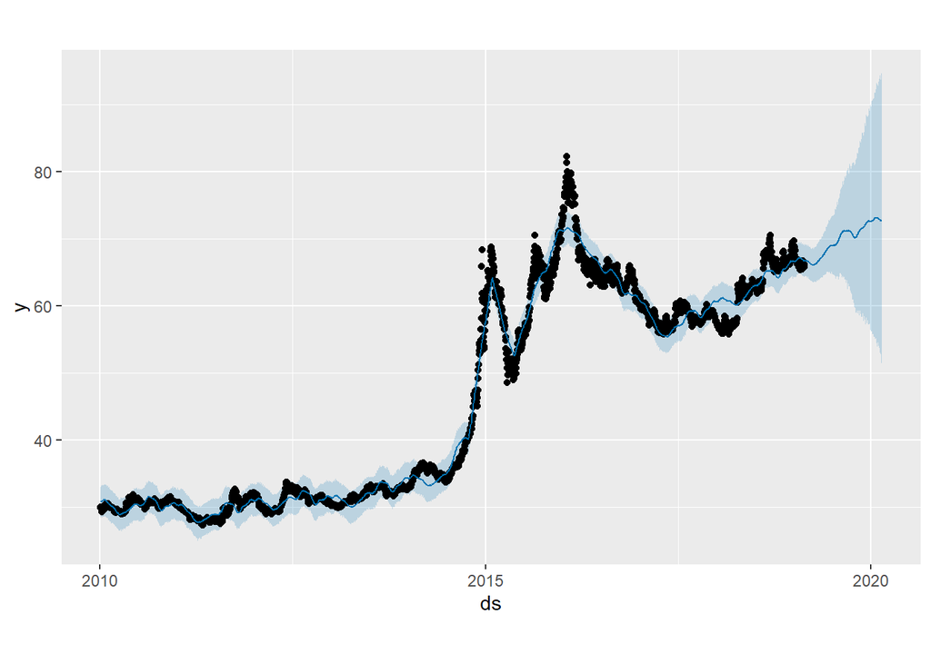

```r
plot(r_ruble1, forecast_ruble)
```

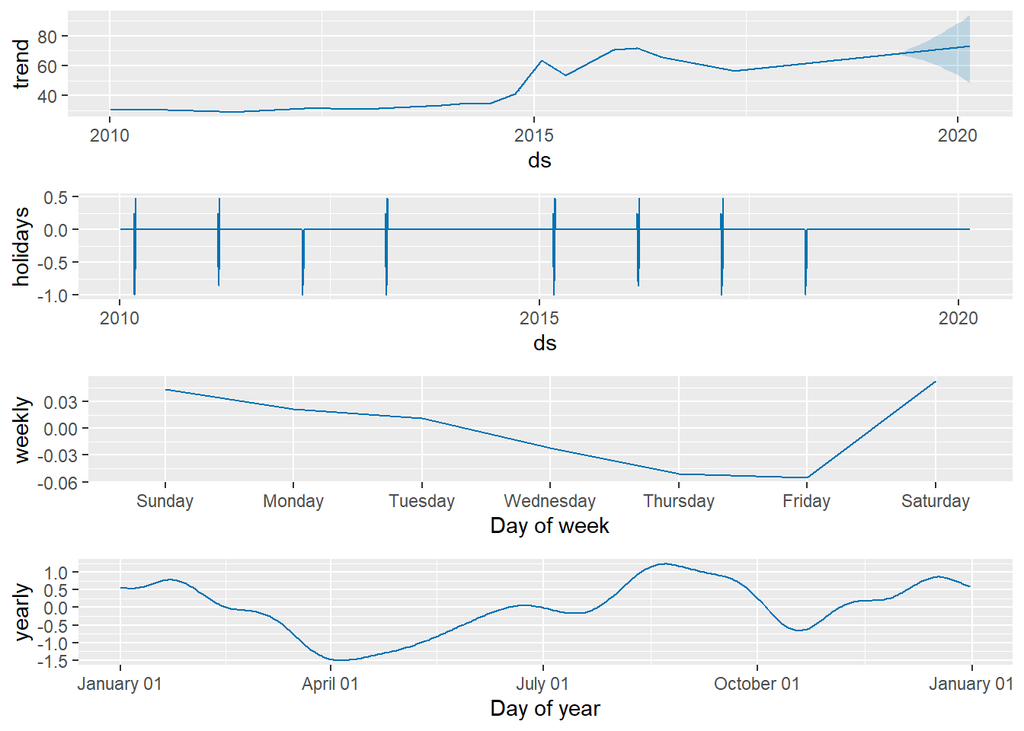

```r
prophet_plot_components(r_ruble1, forecast_ruble1)
```

В выдаче компонент заметим, что появился график оценки влияния праздников из-за этого изменится и прогноз. Аналогично можно задать праздники и их последствия другого типа,например, новогодние праздники. Создать вектор из переменных с праздниками типа `data.frame`. И учесть при прогнозе влияние праздников каждого типа.

Посмотреть влияние эффекта праздника можно вот так

```r
forecast_ruble1 %>%
  select(ds, march_8) %>%
  filter(abs(march_8) > 0) %>%
  tail(10)
```

```
##            ds    march_8
## 44 2017-03-07 -0.8597847
## 45 2017-03-08 -0.3897317
## 46 2017-03-09 -0.5984843
## 47 2017-03-10  0.4723246
## 48 2018-03-04 -0.5701713
## 49 2018-03-05 -0.9991426
## 50 2018-03-06 -0.7941367
## 51 2018-03-07 -0.8597847
## 52 2018-03-08 -0.3897317
## 53 2018-03-09 -0.5984843
```

## Пример 2. Сравнение методов прогнозирования. Импорт России

В прошлой лекции мы построили SARIMA модель для данных по импорту России. Здесь мы попробуем сравнить прогнозирование с пакетом *Prophet* и прогноз по нашей SARIMA модели. Сравнивать будем по значению среднего квадрата ошибки. Для удобства сравнения напишем функцию на R, которая для временного ряда
$$y_1,...y_{bInd},...,y_k,y_{k+1},....,y_T$$
,начиная с момента времени $bInd$, получает исторический прогноз на один шаг времени $\widehat{y}_{k}(1)$ для всех моментов времени $k=bInd,...,T$ по SARIMA модели оцененной по значениям ряда $y_1,...y_{bInd},...,y_k$

Затем сравним результаты с прогнозированием и использованим пакета *prophet*

```r
library(TSA)
arma.Predict<-function(x,p,d,q,P,D,Q,S,indBegin)
{
  n <- length(x)
  y <- x[1:(indBegin-1)]
  forec <- rep(NA,indBegin)
  up_level <-forec
  dn_level <-forec
  for (i in indBegin:(n-1))
  {
    y <- c(y,x[i])
    model <-  arima(y,order = c(p,d,q),seasonal = list(order = c(P,D,Q),period=S), method="CSS")
    pfar<-predict(model,n.ahead = 1)
    forec <- c(forec,pfar$pred[1])
    up_level <-c(up_level,pfar$pred[1]+pfar$se[1])
    dn_level <-c(dn_level,pfar$pred[1]-pfar$se[1])
  }
  return (list(pred = forec,up_level=up_level,dn_level = dn_level ))
}
```

Читаем данные по ипорту

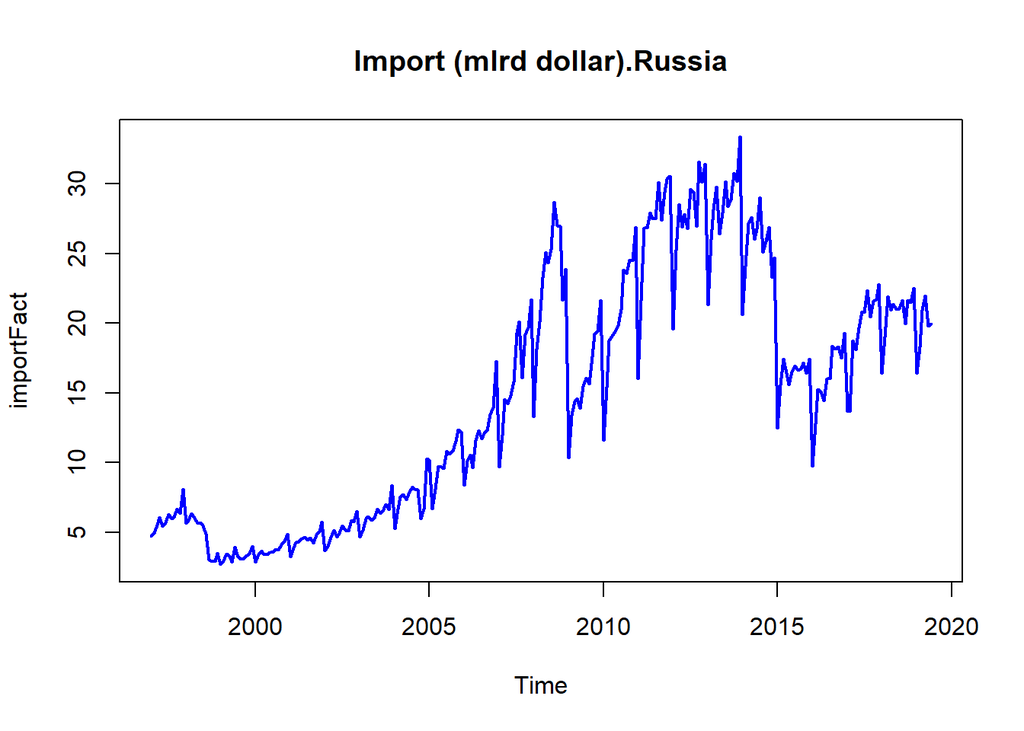

```r
import <- read.csv("./import.csv", header = TRUE)
importFact <- ts(import$Fact ,start= c(1997,1),frequency =12)
plot(importFact ,type = "l", col = "blue",lwd = 2,main = "Import (mlrd dollar).Russia")
```

Напомним, что в прошлых двух лекциях к данному ряду мы идентифицировали сезонную модель SARIMA(0,1,3)(0,1,1) с периодом сезонности 12. Пусть $bInd = 100$. Начиная с $bInd$ и до конца временного ряда, получим исторический прогноз с помощью нашей функции `arma.Predict()`

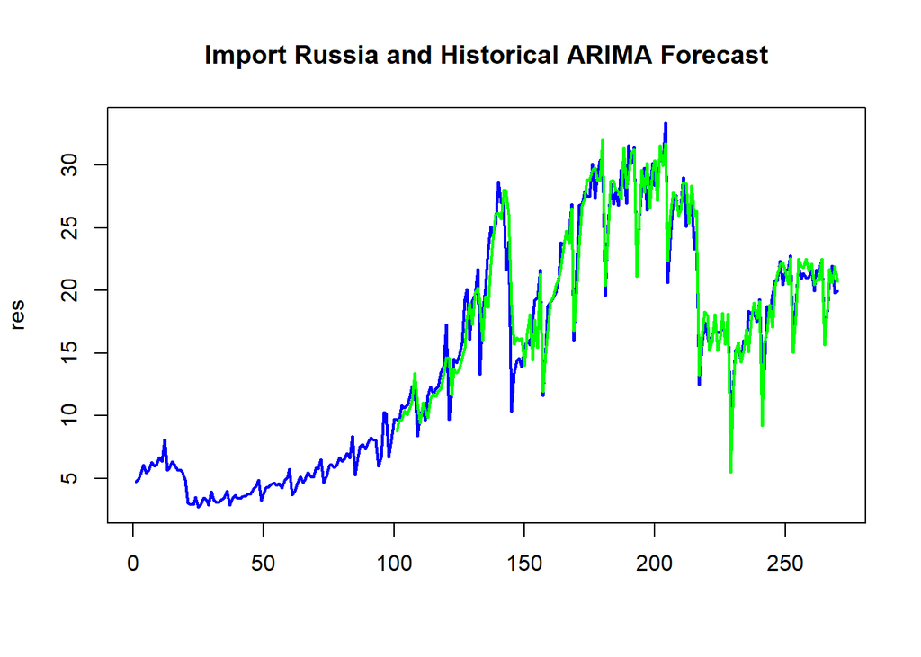

```r
bInd <- 100
p <-  0
d <- 1
q<- 3
P <- 0
D <- 1
Q<- 1
S <-12
SARIMA.Predict<-  arma.Predict(importFact,p,d,q,P,D,Q,S,bInd)
SARIMA.Predict$pred <- ts(SARIMA.Predict$pred ,start= c(1997,1),frequency =12)
res <- cbind(importFact,SARIMA.Predict$pred)
matplot(res ,type = "l",pch = 21, col = c("blue","green"),lty = 1,lwd = 2,main = "Import Russia and Historical ARIMA Forecast")
```

Подготовим данные для пакета `prophet`.

```r
n <- length(SARIMA.Predict$pred)
ds <- seq(as.Date("1997/1/1"), by = 'month', length.out = n)
import.data <- data.frame(ds = ds,y = importFact)
head(import.data,12)
```

```
##            ds     y
## 1  1997-01-01 4.730
## 2  1997-02-01 4.965
## 3  1997-03-01 5.545
## 4  1997-04-01 6.062
## 5  1997-05-01 5.411
## 6  1997-06-01 5.694
## 7  1997-07-01 6.324
## 8  1997-08-01 6.001
## 9  1997-09-01 6.083
## 10 1997-10-01 6.686
## 11 1997-11-01 6.355
## 12 1997-12-01 8.127
```

Оцениваем `prophet` модель и смотрим результат. Даже без вычисления среднего квадрата ошибки прогноза видно,что SARIMA модель лучше

```r
Prophet.model <- prophet(import.data)
```

```
## Disabling weekly seasonality. Run prophet with weekly.seasonality=TRUE to override this.
```

```
## Disabling daily seasonality. Run prophet with daily.seasonality=TRUE to override this.
```

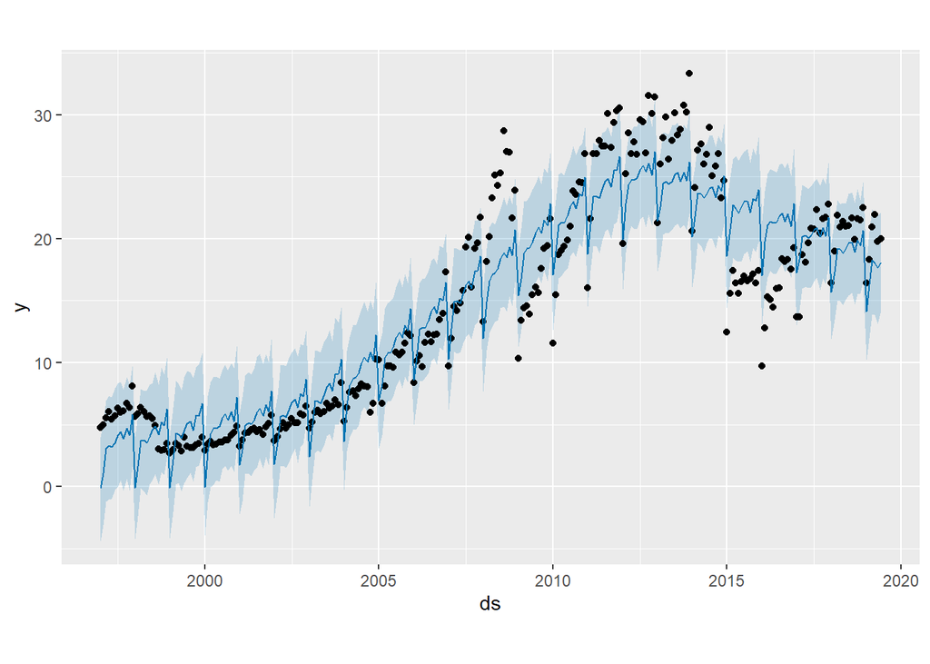

```r
Prophet.predict <- predict(Prophet.model)
plot(Prophet.model, Prophet.predict)
```

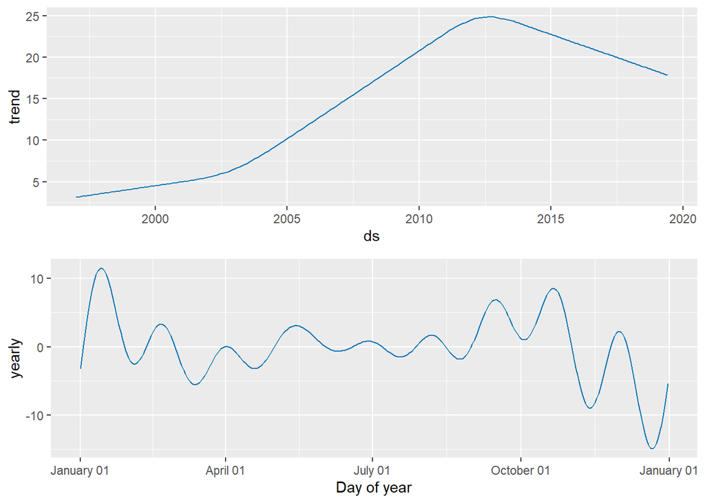

```r
prophet_plot_components(Prophet.model, Prophet.predict)
```

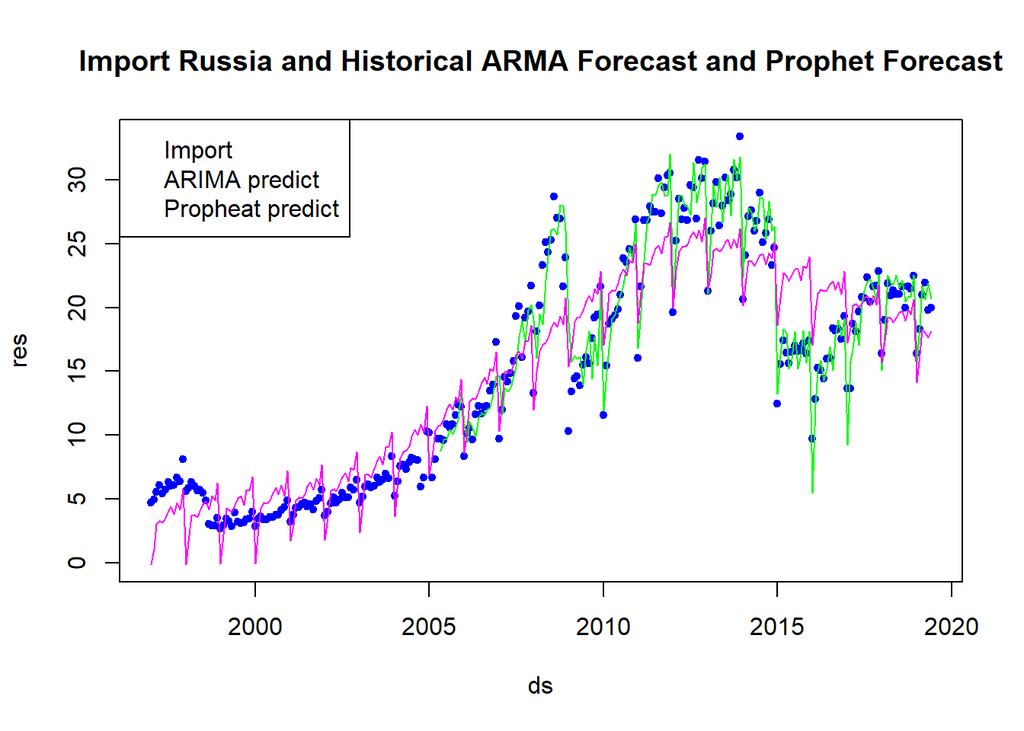

```r
res <- cbind(importFact,SARIMA.Predict$pred,Prophet.predict$yhat)
matplot(ds,res ,type = c("p","l","l"),pch = 20, col = c("blue","green","magenta"),lty = 1,lwd = 1,main = "Import Russia and Historical ARMA Forecast and Prophet Forecast")
legend("topleft",c("Import","ARIMA predict","Propheat predict"),col = c("blue","green","magenta"))
```